# fPQRHMMal

Thomas Whitehead

12/13/2022

This package `fPQRHMMal` performs dimension reduction for Quantile Regression by combining the `fPQR` algorithm developed by Civieta et al. in 2021, and the `HMM` algorithm developed by Bar et al. in 2021. It uses source codes from the `QREM` and `SEMMS` packages written by Haim Bar and is partially based on the `fpqr` package written by Álvaro Méndez Civieta

`fPQRHMMal` can be loaded using the “library” command

```r
library(fPQRHMMal)
```

### fPQR_fit

The `fPQR_fit` function takes as inputs a predictor matrix $X_0$, response matrix $Y_0$, and quantile $q$. It then decomposes $X_0$ into a score matrix $T$ that has maximal quantile covariance with $Y_0$. Then, using an HMM algorithm, it performs variable selection for quantile regression of $Y$ on $T$. Finally, it fits the chosen model for quantile regression of $Y$ on $T$, and then converts the resulting coefficients into coefficients $\hat{\beta}_q$ for $X_0$. The output is a list that includes $\hat{\beta}_q$, the fitted model of $Y_0$ on $T$, and the run times for decomposition of $Y_0$ into $T$, variable selection, model fitting, and coefficient transformation. An example with randomly generated $X_0$ and $Y_0$ and $q=0.5$ is given below, along with plot of the predicted vs actual coefficients of the model.

```r
library(MASS)
X_0=mvrnorm(150, mu=rep(0,100), Sigma=diag(100))
beta=rep(1,101)
Y_0= beta[1]+ X_0%*%beta[-1] + rnorm(100)
mod=fPQR_fit(X_0[1:100,],as.matrix(Y_0[1:100]),0.5)
```

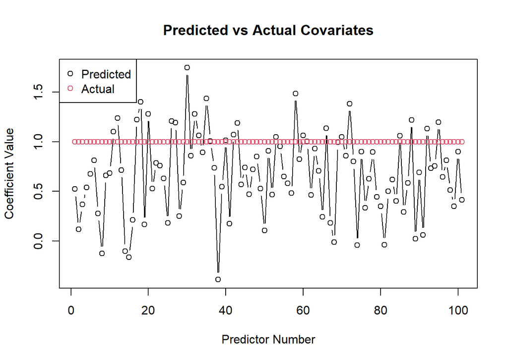

# qcov_li

`qcov_li` is used during`fPQr_fit` to calculate a quantile analog of covariance developed by Li et al. in 2015,

```r
quantile_cov=qcov_li(as.matrix(X_0[,1]), Y_0, 0.5)
quantile_cov
```

```
##              [,1]
## [1,] -0.005703914
```

# signflip_svd

`signflip_svd` is used during the `fPQR_fit` to maintain consistency across multiple Singular Value Decompositions. Its inputs are the first column of $U$ ($u_1$) and the first row of $V$ ($v_1$) from the SVD of the matrix $S_{1,q}S_{1_q}^t=qcov_{li}(X_0,Y_0,q)qcov_{li}(X_0,Y_0,q)^t$

If the largest value of first column $u_1$ is positive, then `signflip_svd` outputs $u_1$ and $v_1$. If the largest value of $u_1$ is negative, then `signflip_svd` outputs $-u_1$ and $-v_1$.

```r
cov=qcov_li(as.matrix(X_0), Y_0, 0.5)%*% t(qcov_li(as.matrix(X_0), Y_0, 0.5))
u_1=svd(cov)$u[,1]
v_1=svd(cov)$v[,1]
flip_u1=signflip_svd(u_1, v_1)
#Original u
u_1[1:10]
```

```
##  [1] -0.01043955  0.08807445  0.11477261  0.14706369  0.13831292 -0.03517374
##  [7] -0.01563985 -0.02258139  0.05509480 -0.00685950
```

```r
#Flipped u
flip_u1[[1]][1:10]
```

```
##  [1] -0.01043955  0.08807445  0.11477261  0.14706369  0.13831292 -0.03517374
##  [7] -0.01563985 -0.02258139  0.05509480 -0.00685950
```

```r
#Original v
v_1[1:10]
```

```
##  [1] -0.01043955  0.08807445  0.11477261  0.14706369  0.13831292 -0.03517374
##  [7] -0.01563985 -0.02258139  0.05509480 -0.00685950
```

```r
#Flipped v
flip_u1[[2]][1:10]
```

```
##  [1] -0.01043955  0.08807445  0.11477261  0.14706369  0.13831292 -0.03517374
##  [7] -0.01563985 -0.02258139  0.05509480 -0.00685950
```

# check_lossTE

`check_lossTE` takes in a proposed solution $\beta_{q}$, test data $X_{test}$ and $Y_{test}$, and q, and calculates the resulting check loss error.

```r
beta_q=mod[[1]]
CL=check_lossTE(beta_q, X_0[101:150,], Y_0[101:150],0.5)
CL
```

```
## [1] 1.802904
```